# Task1:

2023-02-24

# Description

Dans cette tache l’objectif est d’obtenir la matrice de dependance pour un jour choisit. Pour visualiser les differents flux survenu au cours de differentes heures de la journée :

- Selectionner un jour
- Creer la matrice de dépendance pour differents heures de la journée y compris l’heure de pointe
- Afficher la carte de flux pour les heures selectionnées

## 1. Load packages

```r
library(dplyr)
library(sf)
library(leaflet)
library(lubridate)
```

```r
library(mapsf)
library(tidyr)
```

## 2. Load data

```r
heetchPoints <-readRDS("DATA/heetchmarchcrop.Rds")
casaNeib <-st_read("DATA/casaneib.geojson")
```

## 3. Projetion les objets spatiaux

```r
casaNeibProj <-st_transform(casaNeib, crs=26191)
heetchPointsProj <-st_transform(heetchPoints, crs=26191)
```

## 4. Créer la section du 1er Mars

Ici on fixe le jour au 1er Mars

```r
heetchPointsProj$Day <-day(heetchPointsProj$location_at_local_time)
heetchPointsProj$Hour <-hour(heetchPointsProj$location_at_local_time)
heetchM1Proj <-heetchPointsProj %>%
  filter(Day==1)
```

## 5. Intersection des points x et des quartiers y

```r
casaNeibUnion <-st_union(casaNeibProj)
ptsInCasa <-st_contains(x=casaNeibUnion, y=heetchM1Proj)

selectPtsInCasa <-unlist(ptsInCasa)

heetchM1CropProj <-heetchM1Proj[selectPtsInCasa,]
ptsInNeib <-st_within(x=heetchM1Proj, y=casaNeibProj) %>%
  unlist()
heetchM1CropProj$NEIB <-ptsInNeib
```

## 6. Grouper par heure/ par identifiant chauffeur et par quartier

```r
nestedPts <-heetchM1CropProj %>%
  st_drop_geometry() %>%
  group_by(Hour,NEIB, driver_id) %>%
  summarize(NBPTS=n())
```

## 7. Selectionner le quartier principal pour chaque chauffeur à chaque heure

```r
mainNeib <-nestedPts %>%
  group_by(driver_id, Hour) %>%
  arrange(desc(NBPTS)) %>%
  slice(1)
```

## 8. Construire la matrice OD (origine-destination) pour le 1er Mars entre 7H et 8H du matin avec le nombre de drivers

```r
# mainNeibwide a comme colonne(driver_id, hours:00,01...)
mainNeibwide <-mainNeib %>%
  select(driver_id,Hour,NEIB) %>%
  pivot_wider(names_from=Hour,
              values_from=NEIB,
              names_prefix="H",
              values_fill=NA)

OD78 <-mainNeibwide %>%
  group_by(H7,H8) %>%
  summarize(NB=n()) %>%
  filter(!is.na(H7) & !is.na(H8))%>%
  rename(ORI=H7, DES=H8)
```

[output not shown]

```r
OD78$ORINAME <-casaNeib$NAME_4[OD78$ORI]
OD78$DESNAME <-casaNeib$NAME_4[OD78$DES]

polCentroids <- st_centroid(casaNeibProj) # pour avoir les centroides
coordCentroids <-st_coordinates((polCentroids)) %>%as_data_frame()
# pour avoir les coordonnées des centroides
class(coordCentroids)
```

```
## [1] "tbl_df"     "tbl"        "data.frame"
```

```r
OD78$XORI <-coordCentroids$X[OD78$ORI]
OD78$XDES <-coordCentroids$X[OD78$DES]
OD78$YORI <-coordCentroids$Y[OD78$ORI]
OD78$YDES <-coordCentroids$Y[OD78$DES]

head(OD78)
```

```
## # A tibble: 6 × 9
## # Groups:   ORI [2]
##     ORI   DES    NB ORINAME     DESNAME               XORI    XDES   YORI   YDES
##   <int> <int> <int> <chr>       <chr>                <dbl>   <dbl>  <dbl>  <dbl>
## 1     2    10     1 Dar Bouazza Anfa               286219. 289222. 3.29e5 3.34e5
## 2     2    14     1 Dar Bouazza El Maarif          286219. 292859. 3.29e5 3.31e5
## 3     2    15     1 Dar Bouazza Hay Hassani        286219. 289650. 3.29e5 3.31e5
## 4     2    24     1 Dar Bouazza Sidi Belyout       286219. 294346. 3.29e5 3.35e5
## 5     5    10     3 Ain Chock   Anfa               294563. 289222. 3.28e5 3.34e5
## 6     5    11     2 Ain Chock   Assoukhour Assawda 294563. 297072. 3.28e5 3.34e5
```

- Afficher la carte

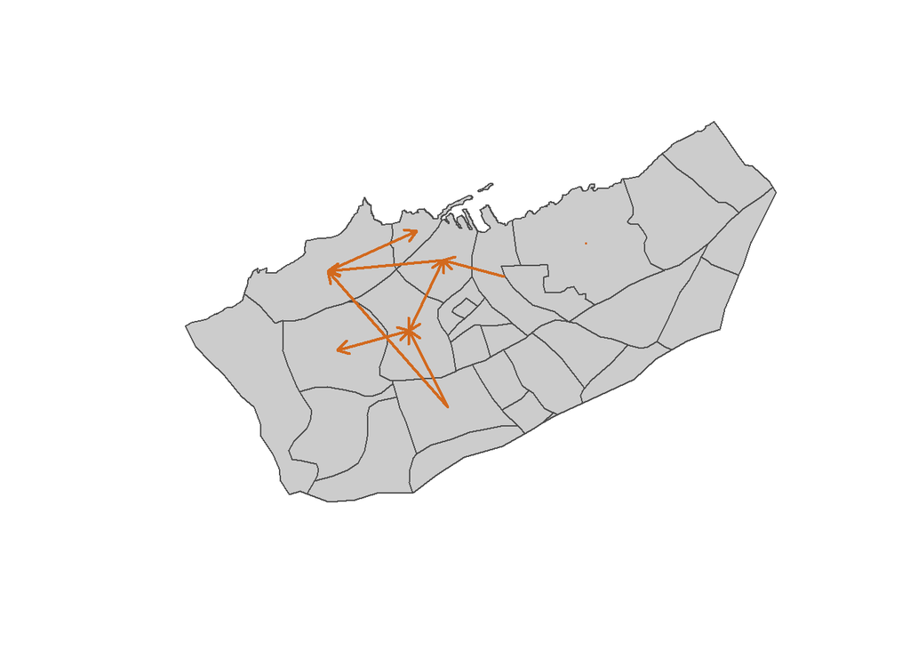

```r
selecFlows <-OD78 %>% filter(NB>2)
plot(casaNeibProj$geometry, col="grey80", border ="grey30")
arrows(selecFlows$XORI,
       selecFlows$YORI,
       selecFlows$XDES,
       selecFlows$YDES,
       col="chocolate",
       lwd=2,
       length=0.1,
       code=2)
```

## 9. Construire la matrice OD (origine-destination) pour le 1er Mars entre 12H et 13H du matin avec le nombre de drivers

```r
OD1213 <-mainNeibwide %>%
  group_by(H12,H13) %>%
  summarize(NB=n()) %>%
  filter(!is.na(H12) & !is.na(H13))%>%
  rename(ORI=H12, DES=H13)
```

[output not shown]

```r
OD1213$ORINAME <-casaNeib$NAME_4[OD1213$ORI]
OD1213$DESNAME <-casaNeib$NAME_4[OD1213$DES]

polCentroids <- st_centroid(casaNeibProj) # pour avoir les centroides
coordCentroids <-st_coordinates((polCentroids)) %>%as_data_frame()
# pour avoir les coordonnées des centroides
class(coordCentroids)
```

```
## [1] "tbl_df"     "tbl"        "data.frame"
```

```r
OD1213$XORI <-coordCentroids$X[OD1213$ORI]
OD1213$XDES <-coordCentroids$X[OD1213$DES]
OD1213$YORI <-coordCentroids$Y[OD1213$ORI]
OD1213$YDES <-coordCentroids$Y[OD1213$DES]

head(OD1213)
```

```
## # A tibble: 6 × 9
## # Groups:   ORI [4]
##     ORI   DES    NB ORINAME      DESNAME               XORI   XDES   YORI   YDES
##   <int> <int> <int> <chr>        <chr>                <dbl>  <dbl>  <dbl>  <dbl>
## 1     2    10     1 Dar Bouazza  Anfa               286219. 2.89e5 3.29e5 3.34e5
## 2     5    24     1 Ain Chock    Sidi Belyout       294563. 2.94e5 3.28e5 3.35e5
## 3     6     7     1 Ain Harrouda Ain Sebaa          306597. 3.01e5 3.39e5 3.35e5
## 4     7     7     4 Ain Sebaa    Ain Sebaa          300709. 3.01e5 3.35e5 3.35e5
## 5     7    11     1 Ain Sebaa    Assoukhour Assawda 300709. 2.97e5 3.35e5 3.34e5
## 6     7    14     1 Ain Sebaa    El Maarif          300709. 2.93e5 3.35e5 3.31e5
```

- Afficher la carte

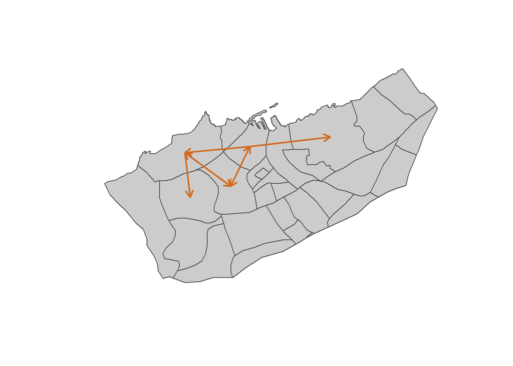

```r
selecFlows <-OD1213 %>% filter(NB>2)
plot(casaNeibProj$geometry, col="grey80", border ="grey30")
arrows(selecFlows$XORI,
       selecFlows$YORI,
       selecFlows$XDES,
       selecFlows$YDES,
       col="chocolate",
       lwd=2,
       length=0.1,
       code=2)
```

```r
OD1819 <-mainNeibwide %>%
  group_by(H18,H19) %>%
  summarize(NB=n()) %>%
  filter(!is.na(H18) & !is.na(H19))%>%
  rename(ORI=H18, DES=H19)
```

[output not shown]

```r
OD1819$ORINAME <-casaNeib$NAME_4[OD1819$ORI]
OD1819$DESNAME <-casaNeib$NAME_4[OD1819$DES]

polCentroids <- st_centroid(casaNeibProj) # pour avoir les centroides
coordCentroids <-st_coordinates((polCentroids)) %>%as_data_frame()
# pour avoir les coordonnées des centroides
class(coordCentroids)
```

```
## [1] "tbl_df"     "tbl"        "data.frame"
```

```r
OD1819$XORI <-coordCentroids$X[OD1819$ORI]
OD1819$XDES <-coordCentroids$X[OD1819$DES]
OD1819$YORI <-coordCentroids$Y[OD1819$ORI]
OD1819$YDES <-coordCentroids$Y[OD1819$DES]

head(OD1819)
```

```
## # A tibble: 6 × 9
## # Groups:   ORI [2]
##     ORI   DES    NB ORINAME     DESNAME               XORI    XDES   YORI   YDES
##   <int> <int> <int> <chr>       <chr>                <dbl>   <dbl>  <dbl>  <dbl>
## 1     2    10     1 Dar Bouazza Anfa               286219. 289222. 3.29e5 3.34e5
## 2     2    11     1 Dar Bouazza Assoukhour Assawda 286219. 297072. 3.29e5 3.34e5
## 3     5     5     1 Ain Chock   Ain Chock          294563. 294563. 3.28e5 3.28e5
## 4     5    11     1 Ain Chock   Assoukhour Assawda 294563. 297072. 3.28e5 3.34e5
## 5     5    14     2 Ain Chock   El Maarif          294563. 292859. 3.28e5 3.31e5
## 6     5    27     1 Ain Chock   Sidi Moumen        294563. 303123. 3.28e5 3.33e5
```

- Afficher la carte

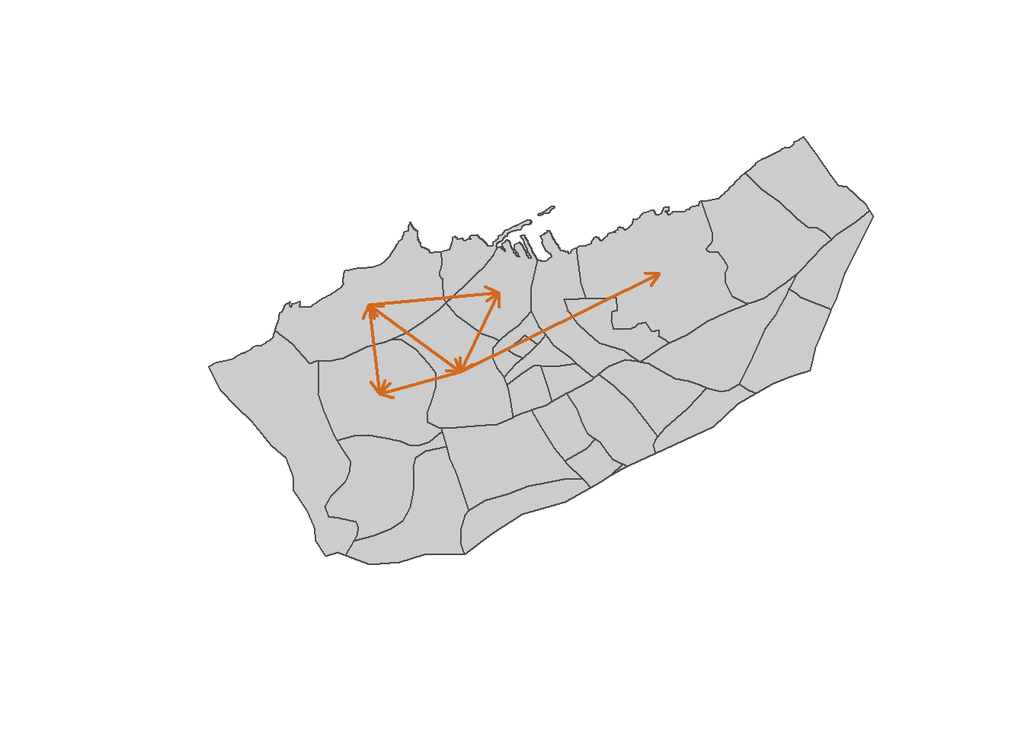

```r
selecFlows <-OD1819 %>% filter(NB>2)
plot(casaNeibProj$geometry, col="grey80", border ="grey30")
arrows(selecFlows$XORI,
       selecFlows$YORI,
       selecFlows$XDES,
       selecFlows$YDES,
       col="chocolate",
       lwd=2,
       length=0.1,
       code=2)
```

# 11. Matrice OD (origine-destination) pour le 1er Mars entre 21H et 22H (heure de pointe) avec le nombre de drivers

```r
OD2122 <-mainNeibwide %>%
  group_by(H21,H22) %>%
  summarize(NB=n()) %>%
  filter(!is.na(H21) & !is.na(H22))%>%
  rename(ORI=H21, DES=H22)
```

[output not shown]

```r
OD2122$ORINAME <-casaNeib$NAME_4[OD2122$ORI]
OD2122$DESNAME <-casaNeib$NAME_4[OD2122$DES]

polCentroids <- st_centroid(casaNeibProj) # pour avoir les centroides
coordCentroids <-st_coordinates((polCentroids)) %>%as_data_frame()
# pour avoir les coordonnées des centroides
class(coordCentroids)
```

```
## [1] "tbl_df"     "tbl"        "data.frame"
```

```r
OD2122$XORI <-coordCentroids$X[OD2122$ORI]
OD2122$XDES <-coordCentroids$X[OD2122$DES]
OD2122$YORI <-coordCentroids$Y[OD2122$ORI]
OD2122$YDES <-coordCentroids$Y[OD2122$DES]

head(OD2122)
```

```
## # A tibble: 6 × 9
## # Groups:   ORI [3]
##     ORI   DES    NB ORINAME     DESNAME           XORI    XDES    YORI    YDES
##   <int> <int> <int> <chr>       <chr>            <dbl>   <dbl>   <dbl>   <dbl>
## 1     2     2     2 Dar Bouazza Dar Bouazza    286219. 286219. 329231. 329231.
## 2     2    14     1 Dar Bouazza El Maarif      286219. 292859. 329231. 331456.
## 3     2    15     1 Dar Bouazza Hay Hassani    286219. 289650. 329231. 330602.
## 4     2    24     1 Dar Bouazza Sidi Belyout   286219. 294346. 329231. 334619.
## 5     4    21     1 Ahl Laghlam Moulay Youssef 305756. 293172. 332604. 335906.
## 6     5     5     2 Ain Chock   Ain Chock      294563. 294563. 328056. 328056.
```

- Afficher la carte

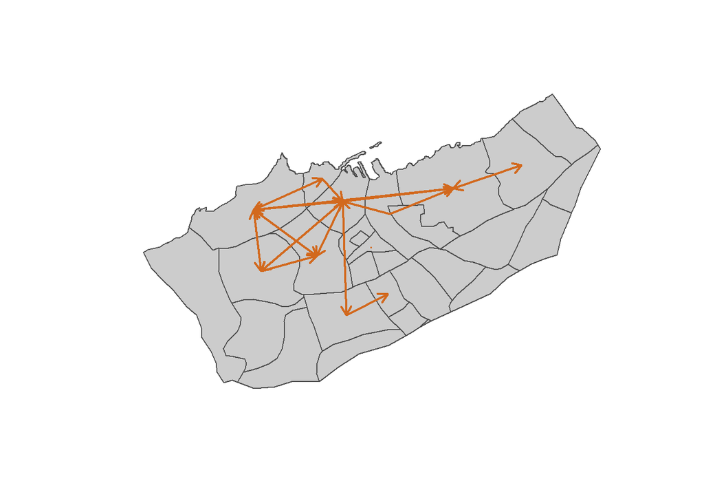

```r
selecFlows <-OD2122 %>% filter(NB>2)
plot(casaNeibProj$geometry, col="grey80", border ="grey30")
arrows(selecFlows$XORI,
       selecFlows$YORI,
       selecFlows$XDES,
       selecFlows$YDES,
       col="chocolate",
       lwd=2,
       length=0.1,
       code=2)
```

# 12. Matrice OD (origine-destination) pour le 1er Mars entre 22H et 23H (1h apres heure de pointe) avec le nombre de drivers

```r
OD2223 <-mainNeibwide %>%
  group_by(H22,H23) %>%
  summarize(NB=n()) %>%
  filter(!is.na(H22) & !is.na(H23))%>%
  rename(ORI=H22, DES=H23)
```

[output not shown]

```r
OD2223$ORINAME <-casaNeib$NAME_4[OD2223$ORI]
OD2223$DESNAME <-casaNeib$NAME_4[OD2223$DES]

polCentroids <- st_centroid(casaNeibProj) # pour avoir les centroides
coordCentroids <-st_coordinates((polCentroids)) %>%as_data_frame()
# pour avoir les coordonnées des centroides
class(coordCentroids)
```

```
## [1] "tbl_df"     "tbl"        "data.frame"
```

```r
OD2223$XORI <-coordCentroids$X[OD2223$ORI]
OD2223$XDES <-coordCentroids$X[OD2223$DES]
OD2223$YORI <-coordCentroids$Y[OD2223$ORI]
OD2223$YDES <-coordCentroids$Y[OD2223$DES]

head(OD2223)
```

```
## # A tibble: 6 × 9
## # Groups:   ORI [2]
##     ORI   DES    NB ORINAME     DESNAME         XORI    XDES    YORI    YDES
##   <int> <int> <int> <chr>       <chr>          <dbl>   <dbl>   <dbl>   <dbl>
## 1     2     2     4 Dar Bouazza Dar Bouazza  286219. 286219. 329231. 329231.
## 2     2    10     1 Dar Bouazza Anfa         286219. 289222. 329231. 334119.
## 3     2    24     1 Dar Bouazza Sidi Belyout 286219. 294346. 329231. 334619.
## 4     5     5     1 Ain Chock   Ain Chock    294563. 294563. 328056. 328056.
## 5     5     9     2 Ain Chock   Al Idrissia  294563. 296955. 328056. 331189.
## 6     5    14     1 Ain Chock   El Maarif    294563. 292859. 328056. 331456.
```

- Afficher la carte

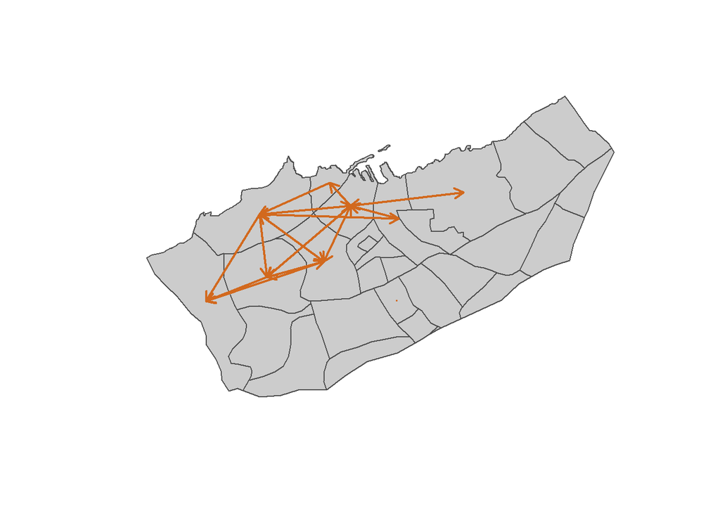

```r
selecFlows <-OD2223 %>% filter(NB>2)
plot(casaNeibProj$geometry, col="grey80", border ="grey30")
arrows(selecFlows$XORI,
       selecFlows$YORI,
       selecFlows$XDES,
       selecFlows$YDES,
       col="chocolate",
       lwd=2,
       length=0.1,
       code=2)
```

Remarque: On constate à travers les differents graphique que le flux est plus important au tour de trois points comme on peut le voir sur le carte. Mais aussi que les flux deviennent de plus en plus important dans les heures du soir au alentour de 22H.